# Group Shape Differences

# Design Matrices: Factorial Models (Cont.)

Note the redundancy

```r
Xg %*% Bg
```

```
##    [,1]
## 15  1.0
## 16  1.0
## 17  5.0
## 18  5.0
## 40  3.0
## 41  3.0
## 42  5.5
## 43  5.5
```

```r
Xf %*% Bf
```

```
##    [,1]
## 15  1.0
## 16  1.0
## 17  5.0
## 18  5.0
## 40  3.0
## 41  3.0
## 42  5.5
## 43  5.5
```

# Design Matrices: Factorial Models (Cont.)

So why bother with a more complicated model design matrix?

Because these do not make sense unless this **factorial** design was used

```r
model.matrix(~ Sex, data = df)
```

```
##    (Intercept) SexM
## 15           1    0
## 16           1    0
## 17           1    1
## 18           1    1
## 40           1    0
## 41           1    0
## 42           1    1
## 43           1    1
## attr(,"assign")
## [1] 0 1
## attr(,"contrasts")
## attr(,"contrasts")$Sex
## [1] "contr.treatment"
```

```r
model.matrix(~ Sex + Pop, data = df)
```

```
##    (Intercept) SexM PopSinkhole
## 15           1    0           0
## 16           1    0           0
## 17           1    1           0
## 18           1    1           0
## 40           1    0           1
## 41           1    0           1
## 42           1    1           1
## 43           1    1           1
## attr(,"assign")
## [1] 0 1 2
## attr(,"contrasts")
## attr(,"contrasts")$Sex
## [1] "contr.treatment"
##
## attr(,"contrasts")$Pop
## [1] "contr.treatment"
```

# Design Matrices: Factorial Models (Cont.)

So why bother with a more complicated model design matrix?

The two models before were sub-models of this full one

```r
Xf
```

```
##    (Intercept) SexM PopSinkhole SexM:PopSinkhole
## 15           1    0           0                0
## 16           1    0           0                0
## 17           1    1           0                0
## 18           1    1           0                0
## 40           1    0           1                0
## 41           1    0           1                0
## 42           1    1           1                1
## 43           1    1           1                1
## attr(,"assign")
## [1] 0 1 2 3
## attr(,"contrasts")
## attr(,"contrasts")$Sex
## [1] "contr.treatment"
##
## attr(,"contrasts")$Pop
## [1] "contr.treatment"
```

# Design Matrices: Factorial Models (Cont.)

With a factorial model, $SS$ can be partitioned (with type I $SS$) for more effects, and greater inference is possible.

```r
fitg <- procD.lm(y ~ Group, data = df, iter = 999, SS.type = "I", print.progress = FALSE)
fitf <- procD.lm(y ~ Sex * Pop, data = df, iter = 999, SS.type = "I", print.progress = FALSE)

anova(fitg)
```

```
##
## Analysis of Variance, using Residual Randomization
## Permutation procedure: Randomization of null model residuals
## Number of permutations: 1000
## Estimation method: Ordinary Least Squares
## Sums of Squares and Cross-products: Type I
## Effect sizes (Z) based on F distributions
##
##           Df     SS     MS     Rsq      F      Z Pr(>F)
## Group      3 25.375 8.4583 0.74908 3.9804 1.2277  0.088 .
## Residuals  4  8.500 2.1250 0.25092
## Total      7 33.875
## ---
## Signif. codes:  0 '***' 0.001 '**' 0.01 '*' 0.05 '.' 0.1 ' ' 1
##
## Call: procD.lm(f1 = y ~ Group, iter = 999, SS.type = "I", data = df,
##     print.progress = FALSE)
```

```r
anova(fitf)
```

```
##
## Analysis of Variance, using Residual Randomization
## Permutation procedure: Randomization of null model residuals
## Number of permutations: 1000
## Estimation method: Ordinary Least Squares
## Sums of Squares and Cross-products: Type I
## Effect sizes (Z) based on F distributions
##
##           Df     SS     MS     Rsq      F      Z Pr(>F)
## Sex        1 21.125 21.125 0.62362 9.9412 1.7554 0.0170 *
## Pop        1  3.125  3.125 0.09225 1.4706        0.2560
## Sex:Pop    1  1.125  1.125 0.03321 0.5294        0.4865
## Residuals  4  8.500  2.125 0.25092
## Total      7 33.875
## ---
## Signif. codes:  0 '***' 0.001 '**' 0.01 '*' 0.05 '.' 0.1 ' ' 1
##
## Call: procD.lm(f1 = y ~ Sex * Pop, iter = 999, SS.type = "I", data = df,
##     print.progress = FALSE)
```

# A More Practical Example (from before)

```r
fitPup <- procD.lm(coords ~ Sex * Pop, data = pupfish, iter = 999, SS.type = "I", print.progress = FALSE)
anova(fitPup)
```

```
##
## Analysis of Variance, using Residual Randomization
## Permutation procedure: Randomization of null model residuals
## Number of permutations: 1000
## Estimation method: Ordinary Least Squares
## Sums of Squares and Cross-products: Type I
## Effect sizes (Z) based on F distributions
##
##           Df       SS        MS     Rsq      F      Z Pr(>F)
## Sex        1 0.015780 0.0157802 0.28012 28.209 5.4040  0.001 **
## Pop        1 0.009129 0.0091294 0.16206 16.320 5.1010  0.001 **
## Sex:Pop    1 0.003453 0.0034532 0.06130  6.173 3.7625  0.001 **
## Residuals 50 0.027970 0.0005594 0.49651
## Total     53 0.056333
## ---
## Signif. codes:  0 '***' 0.001 '**' 0.01 '*' 0.05 '.' 0.1 ' ' 1
##
## Call: procD.lm(f1 = coords ~ Sex * Pop, iter = 999, SS.type = "I",
##     data = pupfish, print.progress = FALSE)
```

# A More Practical Example (from before, Cont.)

```r
plot(fitPup, type = "PC", pch = 21, bg = pupfish$Group)
legend("topright", levels(pupfish$Group), pch = 21, pt.bg = 1:4)
```

[output not shown]

#### Conclusion (with visual help): The interaction between $Sex$ and $Population$ was significant, which indicated sexual dimorphism varied between populations. There is greater sexual dimorphism in the Marsh population compared to the Sinkhole population.

# Design Matrices: Factorial Models (Cont.)

One last comment about the factorial model design,

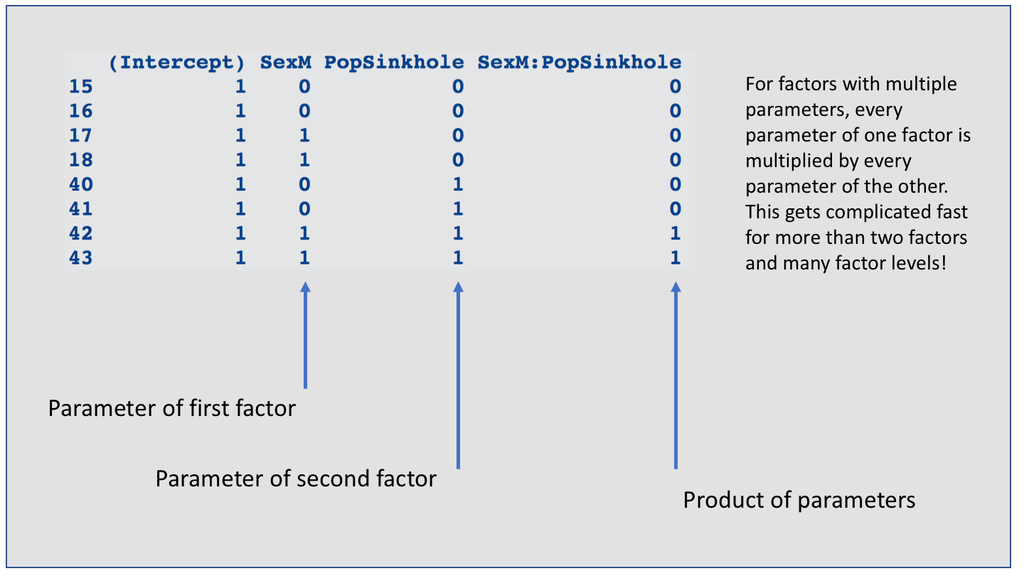

# Multiple Model Effects

It might be apparent with the previous example, or any other example with which one might familiar, that there is often more than a null model and a full model. There might be different **effects** that could be considered for different sets of parameters. In the pupfish example, we might ask whether $Sex$ or $Population$ contribute more to the dispersion in means. We might also wonder if the $Sex$ effect varies between populations.

Not to worry! The model comparison approach can be done in sequence for different model effects. There are only a few little twists with which to be concerned.

#### Preliminaries:

1. Let **null** refer to the model with only an intercept and whose purpose is to estimate an overall mean.
2. Let **reduced** refer to a model with limited parameters, which serves as a basis for comparison.
3. Let **full** refer to a model with all parameters of the reduced model, plus parameters for an effect of interest.

In the initial pupfish example, the null and reduced models were the same; the full model had parameters to estimate four group means. We are going to use the same model now to consider partial effects associated with the dispersion of the four means.

# Multiple Model Effects (Type I SS)

In the pupfish example, we could have the following set of model comparisons to estimate different effects

| Effect | Reduced | Full | Purpose |
| --- | --- | --- | --- |
| Sex | Null | Null + Sex | Determine if Sex mean difference is “significant” compared to an overall mean |
| Pop | Null + Sex | Null + Sex + Pop | Determine if population differences are significant, after accounting for general difference between males and females |
| Sex:Pop | Null + Sex + Pop | Null + Sex + Pop + Sex:Pop | Determine if sexual dimorphism varies between populations, after accounting for general difference in sex and population. |
| Full model | Null | Null + Sex + Pop + Sex:Pop | Ascertain if the model is significant (if not, the other parts should not be considered significant either) |

Estimating $SS$ between models for the first three model comparisons is called **Sequential (Type I) $SS$** estimation. We start with a null model and build up to the fullest model.

# Multiple Model Effects (Type II SS)

In the pupfish example, we could have the following set of model comparisons to estimate different effects

| Effect | Reduced | Full | Purpose |
| --- | --- | --- | --- |
| Sex | Null + Pop | Null + Pop + Sex | Determine if Sex mean difference is “significant”, after accounting for population mean difference |
| Pop | Null + Sex | Null + Sex + Pop | Determine if population differences are significant, after accounting for general difference between males and females |
| Sex:Pop | Null + Sex + Pop | Null + Sex + Pop + Sex:Pop | Determine if sexual dimorphism varies between populations, after accounting for general difference in sex and population. |
| Full model | Null | Null + Sex + Pop + Sex:Pop | Ascertain if the model is signficant (if not, the other parts should not be considered significant either) |

Estimating $SS$ between models for the first three model comparisons is called **Conditional (Type II) $SS$** estimation. We analyze effects with respect to other effects, but do not include interactions with targeted effects. For example, with three factors, A, B, and C. The effect A would have a reduced model of B, C, and B:C. The full model would add A to these. The effect A:B, would have a reduced model of A, B, C, and B:C, and the full model would add A:B to these.

# Multiple Model Effects (Type III SS)

In the pupfish example, we could have the following set of model comparisons to estimate different effects

| Effect | Reduced | Full | Purpose |
| --- | --- | --- | --- |
| Sex | Null + Pop + Pop:Sex | Null + Pop + Sex + Pop:Sex | Determine if Sex mean difference is “significant”, after accounting for all other effects |
| Pop | Null + Sex + Pop:Sex | Null + Sex + Pop + Pop:Sex | Determine if population differences are significant, after accounting for all other effects. |
| Sex:Pop | Null + Sex + Pop | Null + Sex + Pop + Sex:Pop | Determine if sexual dimorphism varies between populations, after accounting for general difference in sex and population. |
| Full model | Null | Null + Sex + Pop + Sex:Pop | Ascertain if the model is signficant (if not, the other parts should not be considered significant either) |

Estimating $SS$ between models for the first three model comparisons is called **Marginal (Type III) $SS$** estimation. Whereas Type I $SS$ evaluates the importance of effects through inclusion, Type III $SS$ evaluates the importance of effects through exclusion.

# Example: Types of SS

```r
fit1 <- procD.lm(coords ~ Pop * Sex, data = pupfish, iter = 999, SS.type = "I", print.progress = FALSE)
fit2 <- procD.lm(coords ~ Pop * Sex, data = pupfish, iter = 999, SS.type = "II", print.progress = FALSE)
fit3 <- procD.lm(coords ~ Pop * Sex, data = pupfish, iter = 999, SS.type = "III", print.progress = FALSE)

anova(fit1)
```

```
##
## Analysis of Variance, using Residual Randomization
## Permutation procedure: Randomization of null model residuals
## Number of permutations: 1000
## Estimation method: Ordinary Least Squares
## Sums of Squares and Cross-products: Type I
## Effect sizes (Z) based on F distributions
##
##           Df       SS        MS     Rsq      F      Z Pr(>F)
## Pop        1 0.008993 0.0089927 0.15964 16.076 4.5061  0.001 **
## Sex        1 0.015917 0.0159169 0.28255 28.453 5.3163  0.001 **
## Pop:Sex    1 0.003453 0.0034532 0.06130  6.173 3.7625  0.001 **
## Residuals 50 0.027970 0.0005594 0.49651
## Total     53 0.056333
## ---
## Signif. codes:  0 '***' 0.001 '**' 0.01 '*' 0.05 '.' 0.1 ' ' 1
##
## Call: procD.lm(f1 = coords ~ Pop * Sex, iter = 999, SS.type = "I",
##     data = pupfish, print.progress = FALSE)
```

```r
anova(fit2)
```

```
##
## Analysis of Variance, using Residual Randomization
## Permutation procedure: Randomization of null model residuals
## Number of permutations: 1000
## Estimation method: Ordinary Least Squares
## Sums of Squares and Cross-products: Type II
## Effect sizes (Z) based on F distributions
##
##           Df       SS        MS     Rsq      F      Z Pr(>F)
## Pop        1 0.009129 0.0091294 0.16206 16.320 5.1010  0.001 **
## Sex        1 0.015917 0.0159169 0.28255 28.453 5.3163  0.001 **
## Pop:Sex    1 0.003453 0.0034532 0.06130  6.173 3.7625  0.001 **
## Residuals 50 0.027970 0.0005594 0.49651
## Total     53 0.056333
## ---
## Signif. codes:  0 '***' 0.001 '**' 0.01 '*' 0.05 '.' 0.1 ' ' 1
##
## Call: procD.lm(f1 = coords ~ Pop * Sex, iter = 999, SS.type = "II",
##     data = pupfish, print.progress = FALSE)
```

```r
anova(fit3)
```

```
##
## Analysis of Variance, using Residual Randomization
## Permutation procedure: Randomization of null model residuals
## Number of permutations: 1000
## Estimation method: Ordinary Least Squares
## Sums of Squares and Cross-products: Type III
## Effect sizes (Z) based on F distributions
##
##           Df       SS        MS     Rsq      F      Z Pr(>F)
## Pop        1 0.007479 0.0074790 0.13276 13.370 4.9162  0.001 **
## Sex        1 0.015253 0.0152534 0.27077 27.267 5.4680  0.001 **
## Pop:Sex    1 0.003453 0.0034532 0.06130  6.173 3.7625  0.001 **
## Residuals 50 0.027970 0.0005594 0.49651
## Total     53 0.056333
## ---
## Signif. codes:  0 '***' 0.001 '**' 0.01 '*' 0.05 '.' 0.1 ' ' 1
##
## Call: procD.lm(f1 = coords ~ Pop * Sex, iter = 999, SS.type = "III",
##     data = pupfish, print.progress = FALSE)
```

# Multiple Model Effects (comments)

# Digging deeper: Pairwise Comparisons (more on interactions)

Let’s return to the pupfish body shape example.

An astute observer might start to wonder which pupfish means are different form each other?

One thing of which to be aware, models with interactions provide so much more opportunity than simpler single-factor models. Recall that these models produce the same means:

```r
fitg <- procD.lm(coords ~ Group, data = pupfish, print.progress = FALSE, iter = 999)
fitf <- procD.lm(coords ~ Pop * Sex, data = pupfish, print.progress = FALSE, iter = 999)
fitg
```

```
##
## Linear Model fit with lm.rrpp
##
## Number of observations: 54
## Number of dependent variables: 112
## Data space dimensions: 53
## Sums of Squares and Cross-products: Type I
## Number of permutations: 1000
## Call: procD.lm(f1 = coords ~ Group, iter = 999, data = pupfish, print.progress = FALSE)
```

```r
fitf
```

```
##
## Linear Model fit with lm.rrpp
##
## Number of observations: 54
## Number of dependent variables: 112
## Data space dimensions: 53
## Sums of Squares and Cross-products: Type I
## Number of permutations: 1000
## Call: procD.lm(f1 = coords ~ Pop * Sex, iter = 999, data = pupfish,
##     print.progress = FALSE)
```

Let’s see, however, how pairwise hypothesis tests differ between them.

# Pairwise Comparisons

There are two statistics for pairwise comparisons that might be of interest. Recall that any estimated value is a vector. A vector has two attributes: length and direction. With two or more vectors, these attributes are related. Anyone who has studied trigonometry can attest that two vectors originating from the same point (origin) describe a triangle. The vectors are orientated with an angle between them, and the vector between vector endpoints is also a vector with a direction and length (distance). The following figure illustrates this.

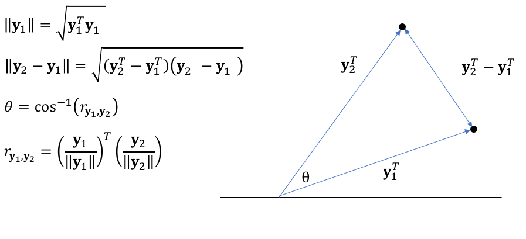

The attributes, vector length (distance, $d$) and angle ($\theta$), can function as test statistics. These statistics have an expected value of 0 under a null hypothesis. (Vector correlation can also be a test statistic, but it has an expected value of 1 for parallel vectors, which is a bit awkward.)

# Pairwise Comparisons (Cont.)

Here is the beautiful thing! I mean this is really, really awesome!

When performing RRPP, we have thousands of random outcomes of coefficients (vectors). These might represent different slopes or ways to estimate vectors between means. Therefore, we inherently have distributions of these geometric statistics. **There is no need for a post-hoc, manufactured test! We can simply generate** *in situ* **distributions from the resampling experiment!**

```r
PWG <- pairwise(fitg, groups = pupfish$Group)
PWF <- pairwise(fitf, groups = pupfish$Group)

PWG
```

```
##
## Pairwise comparisons
##
## Groups: F.Marsh M.Marsh F.Sinkhole M.Sinkhole
##
## RRPP: 1000 permutations
```

```r
PWF
```

```
##
## Pairwise comparisons
##
## Groups: F.Marsh M.Marsh F.Sinkhole M.Sinkhole
##
## RRPP: 1000 permutations
```

For any pairwise test, there is a null model. Let’s see the null models for these pairwise tests:

```r
reveal.model.designs(fitg)
```

```
##        Reduced   Full
## Group        1  Group <- Null/Full inherent in pairwise
```

```r
reveal.model.designs(fitf)
```

```
##            Reduced                 Full
## Pop              1                  Pop
## Sex            Pop            Pop + Sex
## Pop:Sex  Pop + Sex  Pop + Sex + Pop:Sex <- Null/Full inherent in pairwise
```

# Pairwise Comparisons, Example

Now we have choices! For example,

```r
summary(PWG, test.type = "dist") # "dist" for distance between vectors
```

```
##
## Pairwise comparisons
##
## Groups: F.Marsh M.Marsh F.Sinkhole M.Sinkhole
##
## RRPP: 1000 permutations
##
## LS means:
## Vectors hidden (use show.vectors = TRUE to view)
##
## Pairwise distances between means, plus statistics
##                                d  UCL (95%)        Z Pr > d
## F.Marsh:M.Marsh       0.04611590 0.01875366 8.976608  0.001
## F.Marsh:F.Sinkhole    0.03302552 0.01994074 5.226550  0.001
## F.Marsh:M.Sinkhole    0.03881514 0.01890712 6.953850  0.001
## M.Marsh:F.Sinkhole    0.04605211 0.02057201 7.990063  0.001
## M.Marsh:M.Sinkhole    0.02802087 0.01931652 4.120687  0.001
## F.Sinkhole:M.Sinkhole 0.02568508 0.02039267 3.300512  0.003
```

# Pairwise Comparisons, Example (Cont.)

Now we have choices! For example,

```r
summary(PWF, test.type = "dist") # "dist" for distance between vectors
```

```
##
## Pairwise comparisons
##
## Groups: F.Marsh M.Marsh F.Sinkhole M.Sinkhole
##
## RRPP: 1000 permutations
##
## LS means:
## Vectors hidden (use show.vectors = TRUE to view)
##
## Pairwise distances between means, plus statistics
##                                d  UCL (95%)          Z Pr > d
## F.Marsh:M.Marsh       0.04611590 0.04248902  2.4405762  0.007
## F.Marsh:F.Sinkhole    0.03302552 0.03302631  1.6935108  0.051
## F.Marsh:M.Sinkhole    0.03881514 0.04678586 -0.5826772  0.718
## M.Marsh:F.Sinkhole    0.04605211 0.05480284 -0.1850565  0.551
## M.Marsh:M.Sinkhole    0.02802087 0.03348294  0.1316034  0.424
## F.Sinkhole:M.Sinkhole 0.02568508 0.04365689 -2.0609806  0.987
```

# Pairwise Comparisons, Example (Cont.)

Note that in this example, we used `test.type = "dist"` because it makes sense to look at the differences among means in terms of how spread out they are in the data space. Also notice the similarities and differences between the two tests:

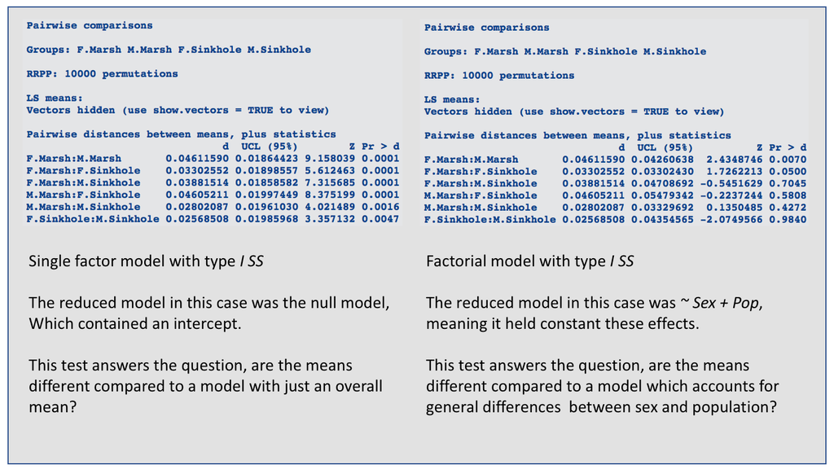

# Pairwise Comparisons, Example (Cont.)

The latter test makes sense, if we look again at the PC plot

```r
plot(fitf, type = "PC", pch = 21, bg = pupfish$Group)
legend("topright", levels(pupfish$Group), pch = 21, pt.bg = 1:4)
```

[output not shown]

The first test tells use means are different. The second test tells use that despite population differences in shape and despite sexual dimorphism, in general, the sexual dimorphism in the Marsh population is greater than the sexual dimorphism in the sinkhole population.

# Pairwise Comparisons, Example (Cont.)

What about comparing slopes among groups that might have different patterns of covariation?

##### We will explore that in the allometry lecture

##### We will also explore ANCOVA designs as lab examples

# Summary

- Group shape differences via linear models
- ANOVA means comparing two models in a systematic way
  - SS types: I, II, III
- RRPP makes ANOVA possible
- RRPP also means pairwise statistics are inherently generated
- Pairwise statistics are geometric attributes
- More on pairwise approaches in *Trajectory Analysis* and *Allometry*